# `dotplot.cv`

Dot plots of cross-validation results

#### Description

Produce dot plots of (average) results from (repeated) K-fold cross-validation.

#### Usage

```
## S3 method for class 'cv'
dotplot(x, data, select = NULL,
seFactor = NA, ...)
## S3 method for class 'cvSelect'
dotplot(x, data, subset = NULL,
select = NULL, seFactor = x$seFactor, ...)
```

#### Arguments

- x an object inheriting from class “cvSelect” that contains cross-validation results. data currently ignored. subset a character, integer or logical vector indicating the subset of models for which to plot the cross-validation results. select a character, integer or logical vector indicating the columns of cross-validation results to be plotted.
- seFactor a numeric value giving the multiplication factor of the standard error for displaying error bars. Error bars can be suppressed by setting this to NA. … additional Arguments to be passed to the “formula” method of dotplot.

#### Examples

```r
library("robustbase")
data("coleman")
set.seed(1234) # set seed for reproducibility
## set up folds for cross-validation
folds <- cvFolds(nrow(coleman), K = 5, R = 10)
## compare LS, MM and LTS regression
# perform cross-validation for an LS regression model
fitLm <- lm(Y ~ ., data = coleman)
cvFitLm <- cvLm(fitLm, cost = rtmspe,
folds = folds, trim = 0.1)
```

```r
# perform cross-validation for an MM regression model
fitLmrob <- lmrob(Y ~ ., data = coleman, k.max = 500)
cvFitLmrob <- cvLmrob(fitLmrob, cost = rtmspe,
folds = folds, trim = 0.1)
```

```r
# perform cross-validation for an LTS regression model
fitLts <- ltsReg(Y ~ ., data = coleman)
cvFitLts <- cvLts(fitLts, cost = rtmspe,
folds = folds, trim = 0.1)
# combine and plot results
cvFits <- cvSelect(LS = cvFitLm, MM = cvFitLmrob, LTS = cvFitLts)
cvFits
```

```
##
## 5-fold CV results:
##   Fit        CV
## 1  LS 1.6501492
## 2  MM 0.9872721
## 3 LTS 1.1407723
##
## Best model:
##   CV
## "MM"
```

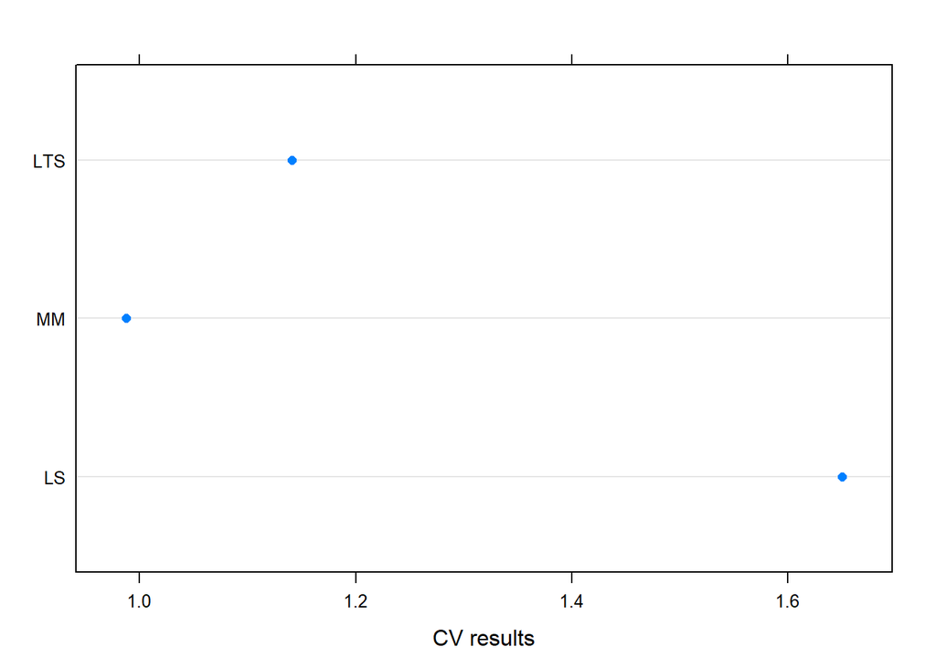

```r
dotplot(cvFits)
```

```r
## compare raw and reweighted LTS estimators for
## 50% and 75% subsets
# 50% subsets
fitLts50 <- ltsReg(Y ~ ., data = coleman, alpha = 0.5)
cvFitLts50 <- cvLts(fitLts50, cost = rtmspe, folds = folds,
fit = "both", trim = 0.1)
# 75% subsets
fitLts75 <- ltsReg(Y ~ ., data = coleman, alpha = 0.75)
cvFitLts75 <- cvLts(fitLts75, cost = rtmspe, folds = folds,
fit = "both", trim = 0.1)
```

```r
# combine and plot results
cvFitsLts <- cvSelect("0.5" = cvFitLts50, "0.75" = cvFitLts75)
cvFitsLts
```

```
##
## 5-fold CV results:
##    Fit reweighted      raw
## 1  0.5   1.140772 1.511817
## 2 0.75   0.963192 1.165930
##
## Best model:
## reweighted        raw
##     "0.75"     "0.75"
```

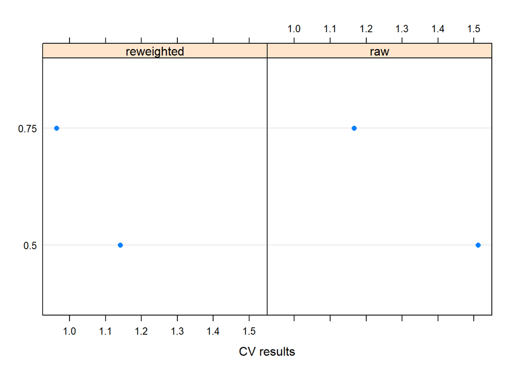

```r
dotplot(cvFitsLts)
```

#### Details

For objects with multiple columns of repeated cross-validation results, conditional dot plots are produced. Value An object of class “trellis” is returned invisibly. The update method can be used to update components of the object and the print method (usually called by default) will plot it on an appropriate plotting device. dotplot.cv 29 Author(s) Andreas Alfons See Also cvFit, cvSelect, cvTuning, plot, xyplot, bwplot, densityplot